# Reproducible Research: Peer Assessment 1

## 1-Loading and preprocessing the data

```r
setwd("~/Desktop/Coursera/D5_Reproducible Research/Week 2/Project_01")
unzip(zipfile = "activity.zip")
data <- read.csv("activity.csv", header= TRUE, colClasses = c("integer", "Date", "integer"))
summary(data)
```

Table of summary data:

```r
##     steps             date               interval
## Min.   :  0.00   Min.   :2012-10-01   Min.   :   0.0
## 1st Qu.:  0.00   1st Qu.:2012-10-16   1st Qu.: 588.8
## Median :  0.00   Median :2012-10-31   Median :1177.5
## Mean   : 37.38   Mean   :2012-10-31   Mean   :1177.5
## 3rd Qu.: 12.00   3rd Qu.:2012-11-15   3rd Qu.:1766.2
## Max.   :806.00   Max.   :2012-11-30   Max.   :2355.0
## NA's   :2304
```

## 2-What is the mean of Total Number of Steps Taken Per Day?

### 2.1- Plot a histogram of Total Number of Steps Taken per day

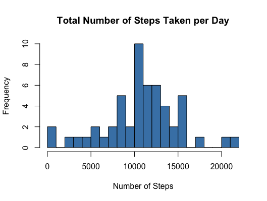

```r
library(ggplot2)
TotalSteps <- tapply(data$steps, data$date, FUN = sum, na.rm =FALSE)


hist(TotalSteps,breaks=20,
     xlab="Number of Steps",
     ylab = "Frequency",
     main = "Total Number of Steps Taken Per Day",
     col = "steelblue")
```

### 2.2- Mean of Total number of steps taken per day

```r
AvgSteps <- mean(TotalSteps, na.rm = TRUE)
formatC(AvgSteps, big.mark = ",", format = "f", digits = 0)
```

Mean of Total Number of Steps Taken Per Day

```r
## [1] "10,766"
```

### 2.3- Median of Total Number of Steps Taken Per Day

```r
MedSteps <- median(TotalSteps, na.rm = TRUE)
formatC(MedSteps, big.mark = ",", format = "f", digits = 0)
```

Median of Total Number of Steps Taken Per Day:

```r
##[1] "10,765"
```

## 3-What is the Average Daily Activity Pattern?

### 3.1-Aggreate the interval and steps data with a 5-minute interval to create a time series plot to identy the average daily activity pattern

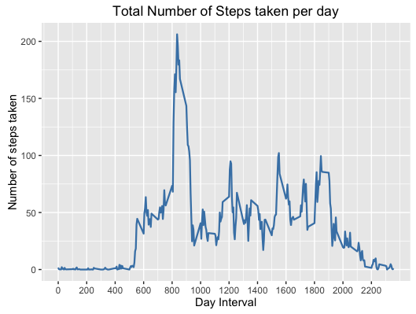

```r
library(ggplot2)
AvgStepsInt <- aggregate(x=list(steps=data$steps), by=list(interval=data$interval),
                         FUN=mean, na.rm=TRUE)

ggplot(AvgStepsInt, aes(x= interval, y=steps)) +
  geom_line(color = "steelblue", size = 0.8) +
  xlab("5-minute interval") +
  ylab("Number of steps taken") +
  ggtitle("Total Number of Steps taken per day") +
  scale_x_continuous("Day Interval", breaks = seq(min(AvgStepsInt$interval),
                                               max(AvgStepsInt$interval), 200))
```

```r
head(AvgStepsInt)
```

### 3.2-Summary table of AvgStepsInt (Average Steps taken per 5-minute Interval)

```r
##  interval     steps
## 1        0 1.7169811
## 2        5 0.3396226
## 3       10 0.1320755
## 4       15 0.1509434
## 5       20 0.0754717
## 6       25 2.0943396
```

### 3.3-Use which.max() to identify the Interval which contains the Max Num of Steps

```r
MaxInterval <- AvgStepsInt[which.max(AvgStepsInt[,2]),1]
MaxInterval
```

Interval that contains the Max Number of Steps is:

```r
## [1] 835
```

```r
MaxSteps <- AvgStepsInt[which.max(AvgStepsInt[,2]),2]
MaxSteps
```

The Max Numer of Steps is :

```r
## [1] 206.1698
```

## 4-Imputing Missing Values (NAs)

### 4.1-Summary of Missing Values (NAs)

```r
sum(is.na(data)) # Summary missing data
```

The Total Missing Value (NAs) is:

```r
## [1] 2304
```

Verify the Total Missing Values (NAs) by calling summary of data table

```r
summary(data)
```

```r
##     steps             date               interval
## Min.   :  0.00   Min.   :2012-10-01   Min.   :   0.0
## 1st Qu.:  0.00   1st Qu.:2012-10-16   1st Qu.: 588.8
## Median :  0.00   Median :2012-10-31   Median :1177.5
## Mean   : 37.38   Mean   :2012-10-31   Mean   :1177.5
## 3rd Qu.: 12.00   3rd Qu.:2012-11-15   3rd Qu.:1766.2
## Max.   :806.00   Max.   :2012-11-30   Max.   :2355.0
## NA's   :2304
```

The data set contains 2304 missing values(NAs), which accounts to 13.1% of all the total intervals.

Devise a strategy for filling in all of the missing values in the dataset. The strategy does not need to be sophisticated. you use the mean/median for that day, or the mean for that 5-minute interval, etc.

### 4.2-Create a new dataset that is equal to the original dataset but with the missing data filled in.

```r
impute.value <- function(steps, interval) {
  imputed <- NA
  if (!is.na(steps))
    imputed  <- c(steps)
  else
    imputed  <- (AvgStepsInt[AvgStepsInt$interval==interval, "steps"])
  return(imputed )
}
```

### 4.3-Merge the imputed data with the newly created dataset with the filled missing data (NAs)

```r
imputed_data <- data
imputed_data$steps <- mapply(impute.value, imputed_data$steps, imputed_data$interval)

Total_Steps <- tapply(imputed_data$steps, imputed_data$date, FUN=sum)
```

### 4.4-Use the imputed data to plot a histogram of the Total Number of Steps Taken Per Day

[figure not shown]

```r
hist(Total_Steps,breaks=20,
     xlab=" Total Number of Steps taken Per day",
     ylab = "Frequency",
     main = "Total Number of Steps Taken Per Day",
     col = "steelblue")
```

### 4.5- Compute the Mean and Median of the Total Number of Steps Taken Per Day with Imputed data

Mean of the Total Number of Steps Taken Per Day with Imputed data:

```r
mean(Total_Steps)
```

```r
##[1] 10766.19
```

Median of the Total Number of Steps Taken Per Day with Imputed data:

```r
median(Total_Steps)
```

```r
##[1] 10766.19
```

## 5-Are there differences in activity patterns between weekdays and weekends?

### 5.1-Create a new variable in the dataset with imputed data to identify whether a given date is a weekday or weekend day.

```r
weekday.or.weekend <- function(date) {
  day <- weekdays(date)
  if (day %in% c("Monday", "Tuesday", "Wednesday", "Thursday", "Friday"))
    return("weekday")
  else if (day %in% c("Saturday", "Sunday"))
    return("weekend")
  else
    stop("invalid date")
}
```

```r
imputed_data$date <- as.Date(imputed_data$date)
imputed_data$day <- sapply(imputed_data$date, FUN=weekday.or.weekend)
```

```r
AvgStepsInt2 <- aggregate(steps ~ interval + day, data=imputed_data, mean)
```

### 5.2- Use ggplot to plot a graphic of Comparasion of Average Number of Steps Taken Between Weekdays and Weekends.

[figure not shown]

```r
ggplot(AvgStepsInt2, aes(interval, steps)) +
  geom_line(color = "steelblue", size = 0.8)  +
  facet_grid(day ~ .) +
  xlab("5-minute interval") +
  ylab("Number of steps") +
  ggtitle("Comparasion of Activity Patterns between Weekdays and Weekends")
```